# Non-parametric estimation of population size changes from the site frequency spectrum

Berit Lindum Waltoft and Asger Hobolth

2017-07-01

# Introduction

This package estimates the population size back in time using a roughness penalty approach. In particular we use a cubic spline to model the integrated colaescent rate.

Let $N(r)$ be the population size at generation $r$ back in time, and let $t=r/N(0)$ be the time in the past in coalescent units. Then the coalescent rate is

$$\lambda(t) = \frac{2N(0)}{2N(t\cdot 2N(0))},$$

and the integrated coalescent rate is $\Lambda(t)=\int_0^t\lambda(s) ds$.

The cubic spline adopts the properties from the integrated coalescent rate, i.e. given som time points $0=t_0<t_1<t_2<\cdots t_m$ the spline fulfills the properties:

- $\Lambda(t) = a_i+b_i(t-t_i)+c_i(t-t_i)^2+d_i(t-t_i)^3$ for $t_i\leq t<t_{i+1}$ and $\Lambda(t) = a_m+b_m(t-t_m)$ for $t_m\leq t$.
- $\Lambda(0)=a_0=0$.
- $\Lambda'(0) = b_0 = \lambda(0) = 1$.
- $\Lambda(t)$ is increasing for all $t \geq 0$.

Given some time points $0=t_0<t_1<t_2<\cdots <t_m$, and the values of the spline in the time points $\Lambda(t_i)=a_i$ for all $i$ the parameters of the spline is determined by a linear equation system.

The spline describing the changes in population size giving rise to the observed SFS $\xi$ based on $n$ sequences is found by minimizing the following score function with respect to $a_1,a_2,\ldots,a_m$:

$$S(\Lambda)= (1-\alpha)\sum\limits_{i=1}^{n-1}\frac{\left(\mathrm{E}[\xi_i]-\xi_i\right)^2}{\mathrm{E}[\xi_i]}+\alpha\int\limits_{0}^{\infty}\left(\Lambda''(t)\right)^2dt$$
,

where $\alpha \in (0,1)$ is a smoothing parameter, and the expected SFS $\mathrm{E}[\xi_i]$ is evaluated by means of the probability of observing a site with $i$ derived alleles given by
$$p_i(\Lambda)=\frac{\sum\limits_{j=2}^n e_j (\Lambda)W_{ij}}{\sum\limits_{j=2}^n e_j(\Lambda)V_j}$$
where
$$e_j(\Lambda) = \int\limits_0^{\infty}\exp\left( -{j \choose 2}\Lambda(t)\right)dt,$$
and $W$ and $V$ are constants defined by Polanski and Kimmel (2003)[^1]. The matrix $W$ and vector $V$ only depend on the number of sequences, and are given by the functions `WFunction` and `VFunction` privided by `CubSFS`.

# An overview of the package

The package consists of multiple functions, which all contribute to the estimation. The main function is `estimateCubSFS` which, given an observed SFS and som time points back in time (in coalescent units) estimates the changes in coalescent rate back in time. The functions `AicCubSFS` and `PlotCubSFS` evaluate the results from `estimateCubSFS` either by calculating the Akaikes Information Criteria (`AicCubSFS`) or by generating plots of the changes dependent on years back in time (`PlotCubSFS`). The following figure displays the dependencies between the functions in the package.

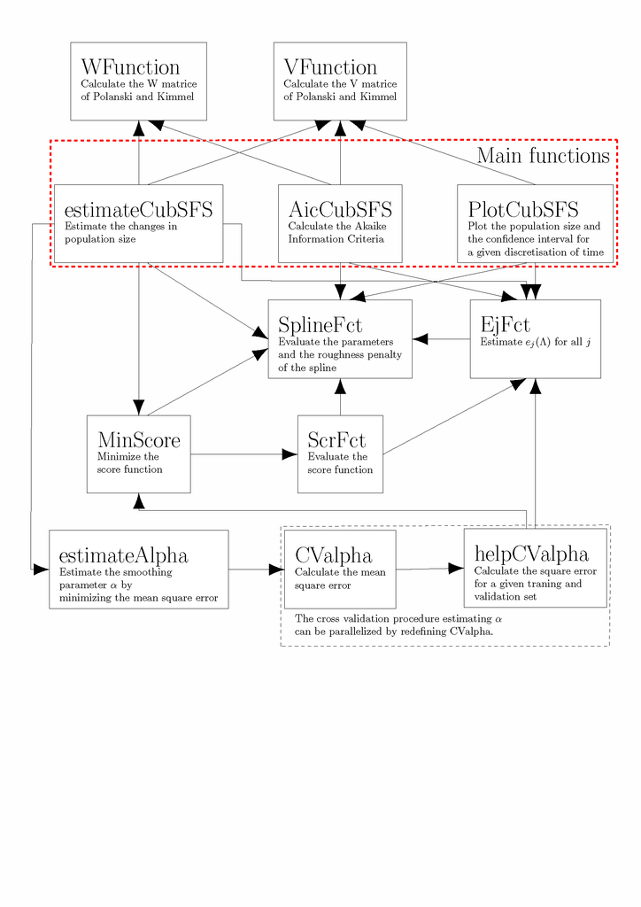

# An example

In the following example we will estimate the changes in population size for one diploid population with an exponetial growth. Notice that the SFS corresponds to that used in the publication[^2], and the data is provided by the `CubSFS` package.

## Generate data from Exponential growth history

The data in the example is from a population with exponential growth, i.e. the coalescent rate is $\lambda(t)=\exp(\delta t)$ and the integrated coalescent rate is $\Lambda(t)=\frac{1}{\delta}(\exp(\delta t)-1)$ for $t$ in coalescent units. Here we let $\delta=2$. Assume a total of 100 diploid individuals, i.e. $n=200$ sequences, are sampled. Assume each sequence has a length of $0.5\cdot 10^9$ base pairs, and the number of segregating sites in one sequence is 6,000,000.

The `ExponentialSFS` data frame from the CUbSFS package holds information on the rounded expected SFS of this exponential growth model, including a total of 200 bootstrap samples.

```r
n.samples <- 200
total.nb.sites <- 0.5*(10^9)
obsSFS <- ExponentialSFS$Exponential[-1]
```

The following code generates an observed SFS from this model. Here we use the probability of having a site with $i$ derived alleles as described above.

```r
## not run
Wmat <- WFunction(n.samples)
Vmat <- VFunction(n.samples)

delta <- 2

Lambda.vec <- Vectorize(function(t){
  1/delta*(exp(delta*t)-1)
})

eFun <- function(t,j){exp(-choose(j,2)*Lambda.vec(t))}
ejFun <- function(j){integrate(eFun,lower=0,upper=Inf,j=j)$value}
v.ejFun <- Vectorize(ejFun)
j <- 2:n.samples
eTrue <- v.ejFun(j)

prob.SFS <- (Wmat%*%eTrue)/as.numeric(Vmat%*%eTrue)

obsSFS <- round(6000000*prob.SFS,digits=0)
```

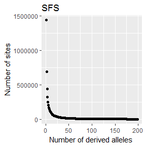

## Estimate the changes in population size

Given a value of the smoothing parameter, e.g. $\alpha=0.25$, the changes in population size is estimated using the `estimateCubSFS` function. Here we use $m=9$ time points different from 0. The last time point is $t_m=0.7633$ (in coalescent units), which is the expected time to most recent ancestor for this exponential model with $n=200$. The time points are destributed almost exponentially on a the coalescent scale by means of
$$t_i = \frac{1}{\kappa}\left\{ \exp\left[ \frac{i}{m}\log(1+\kappa t_m )\right] -1\right\}$$
for $i=0,1,\ldots,m$. Here $\kappa$ determines the clustering of the points close to zero, and by default $\kappa=1$.

The function call looks like this:

```r
res <- estimateCubSFS(obsSFS,n.samples,n.knots=10,t_m=0.7633,alpha= 0.25)
```

The resulting object `res` has the following elements

```
## [1] "ResSpline"    "SFS"          "alpha"        "knots"
## [5] "expSFS"       "CoalRate"     "CoalRatePlot" "SFSPlot"
## [9] "vsPlot"
```

The values `res$knots` are the time points $t_0<t_1<\ldots<t_m$, and the values `cumsum(res$ResSpline$par)` are the functional values in the time points $a_i=\Lambda(t_i)$. The element `ResSpline` holds information on the convergence of the method, and `expSFS` is the expected SFS under the estimated model. The result in coalescent units is presented in the data frame `CoalRate`. Three plots are illustrative of the fit, and look like

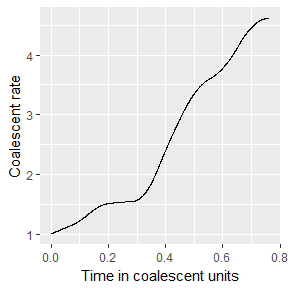

```r
res$CoalRatePlot
```

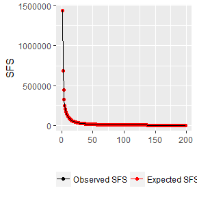

```r
res$SFSPlot
```

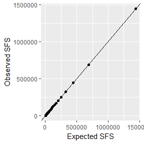

```r
res$vsPlot
```

The plots can be excluded from the output, by setting `add.plot=FALSE`.

One may include user determined time points. However, the user must always include $t_0=0$ and specify the time points in coalescent units.

```r
## not run
timepoints <- c(0,0.25,0.5,0.75,1)
estimateCubSFS(obsSFS,n.samples,knots=timepoints,alpha=0.25)
```

The `estimateCubSFS` function uses the `nloptr::auglag` function to minimize the score function and providing an increasing spline. In order to converge the `nloptr::auglag` function is called succesively until the distrance between the new estimate and the previous estimate is less than `conv.lim` for all parameters. The input of `conv.lim` may be given in the `estimateCubSFS` call. Increasing `conv.lim` will increase the speed of the algorithm, however, decrease the accuracy of the estimate.

## The smoothing parameter

The smoothing parameter $\alpha$ is estimated by cross validation if `alpha=NULL` (default). Notice that this may take a while depending on the number of different validation sets `nb.groups`(default `nb.groups=5`). During the estimation, the user is updated on the convergence of the parameter and the mean goodness of fit (GOF). The accuracy of the result of the cross validation procedure is controlled with `tol` (default `tol= 10^{-2}`)

```r
set.seed(98765)
resAlpha <- estimateCubSFS(obsSFS,n.samples,n.knots=10,t_m=0.7633)
```

```
## alpha = 0.381966 and Mean GOF =  190.0348
## alpha = 0.618034 and Mean GOF =  200.6099
## alpha = 0.236068 and Mean GOF =  215.1263
## alpha = 0.4605334 and Mean GOF =  183.7098
## alpha = 0.4718457 and Mean GOF =  195.7072
## alpha = 0.4244203 and Mean GOF =  193.6256
## alpha = 0.4467394 and Mean GOF =  193.0858
## alpha = 0.4552646 and Mean GOF =  187.1689
## alpha = 0.4648543 and Mean GOF =  191.8911
## alpha = 0.4605334 and Mean GOF =  183.7098
```

The element of `resAlpha` is the same as the elements of `res`. The three plots looks like

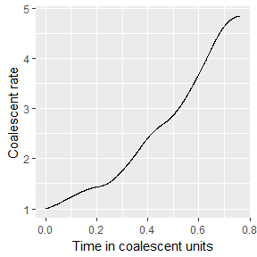

```r
resAlpha$CoalRatePlot
```

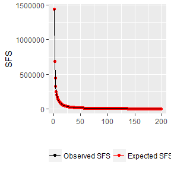

```r
resAlpha$SFSPlot
```

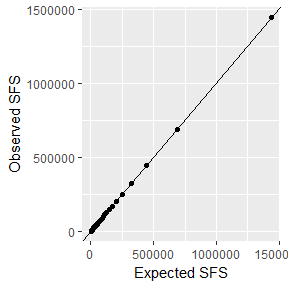

```r
resAlpha$vsPlot
```

However, the `alpha` element of the result now looks like

```
## $minimum
## [1] 0.4605334
##
## $objective
## [1] 183.7098
```

where `resAlpha$alpha$minimum` is the estimate of the smoothing parameter. For a specific value of $\alpha$, the `res$alpha` element has an identical construction as `resAlpha$alpha`, where the minimum value is the value given to the parameter `alpha` of `estimateCubSFS` and the objektive is `NA`.

```
## $minimum
## [1] 0.25
##
## $objective
## [1] NA
```

The implementation of the cross validation procedure in CubSFS is linear. However, this can fairly simple be parallelized by overwriting the `CValpha` function.

For the cross validation procedure all sites used for the observed SFS is randomly grouped into `nb.groups` groups. Each group know constitute a SFS, which is to be used as a validation SFS exactly once. For each validation SFS the other SFSs are added to constitute a training SFS. For each validation set the function `helpCValpha` evaluates the goodness of fit (GOF) of the validation SFS to the inferred model from the training SFS. Each of these GOFs are calculated independently of eachother. The function `CValpha` calls `helpCValpha` `nb.groups` times, to perform the mean GOF. The `CValpha` function is implemented as

```
## function (SFS.groups, nb.groups, knots, theta.prm, alpha, n.samples,
##     Wmat, Vmat, is.folded, nb.time = 500, conv.lim = 10^{
##         -3
##     }, loc.solv = "COBYLA", control = list(maxeval = 20000, ftol_abs = 10^(-5),
##         stopval = 0))
## {
##     fit <- lapply(split(1:nb.groups, as.factor(1:nb.groups)),
##         helpCValpha, SFS.groups = SFS.groups, n.samples = n.samples,
##         knots = knots, theta.prm = theta.prm, alpha = alpha,
##         Wmat = Wmat, Vmat = Vmat, is.folded = is.folded, nb.time = nb.time,
##         conv.lim = conv.lim, loc.solv = loc.solv, control = control)
##     MSE <- mean(unlist(fit))
##     cat("alpha =", alpha, "and Mean GOF = ", MSE, "\n")
##     return(MSE)
## }
## <environment: namespace:CubSFS>
```

The function `estimateAlpha` then uses `optimize`to find the value minizing the mean GOF.

However, since all the call of `helpCValpha` is independent, replacing `lapply` (in the function above) by something like `mclapply` will make the cross validation procedure parallel. On a windows OS take a look at the packages e.g. `snow`, `parallel` or `foreach`. On a Unix and Linux systems this may be easier by simply using e.g. `mclapply` function from the package `parallel`.

## Adding bootstrap samples for confidence limits

Point-wise confidence limits at any time point back in time can be assessed by bootstrap samples. The following code will give `nb.boot` bootstrap samples of the SFS from a multinomial distribution.

```r
set.seed(98765)
nb.boot <- 50
boot <- rmultinom(nb.boot,total.nb.sites,c(total.nb.sites-sum(obsSFS),obsSFS)/total.nb.sites)
boot <- boot[-1,]
```

Running the `estimateCubSFS` function on all of these will enable point-wise confidence limits for the changes in population size back in time. To increase the speed of the algorithm we suppress the plots by adding `add.plot=FALSE`. By specifying `alpha` we do not have to evaluate the smoothing parameter for each bootstrap sample. This may not be optimal for all applications, but is introduced in the interest of running time of this example.

```r
boot.res <- apply(boot,2,estimateCubSFS,n.samples=n.samples,n.knots=10,t_m=0.7633,
                  alpha=resAlpha$alpha$minimum, add.plot=FALSE)
```

Evaluating the smoothing parameter for each bootstrap sample can be done using the following code. Notice that this takes time, however, the estimation is independent for each bootstrap sample, and hence can be parrallized.

```r
## not run
boot.resAlpha <- apply(boot,2,estimateCubSFS,n.samples=n.samples,n.knots=10,t_m=0.7633,add.plot=FALSE)
```

You may want to control the accuracy of the estimate by `tol`. The object `boot.res` is now a list of length `nb.boot` where each element is similar to `res`, and the elements of `boot.resAlpha` are similar to the elements of `resAlpha`, just without the plots.

```r
length(boot.res)
```

```
## [1] 50
```

```r
names(boot.res[[1]])
```

```
## [1] "ResSpline" "SFS"       "alpha"     "knots"     "expSFS"    "CoalRate"
```

## Plotting the final result

For the final plotting we will need some extra information in order to make the transformation from coalescent units to years back in time. If $N(0)$ is provided then the results can be transformed using the transformations described in the introduction. If not then $N(0)$ can be estimated through

$$\qquad\qquad N(0)=\frac{\sum\limits_{i=1}^{n-1} \xi_i}{\mu G \sum\limits_{j=2}^{n}V_je_j(\Lambda)}$$
,

where $\mu$ is the probability of a mutation in one locus betweeen two generations, and $G$ is the total number of base pairs in a sequence. In order to evaluate the change in population size in units of years back in time the generation time is needed.

Assume as an example that $\mu=1.2\cdot10^{-8}$ and that a generation is 24 years.

```r
mu <- 1.2*10^(-8)
genyr <- 24
```

Then the `plotCubSFS` function provided the estimate of the population changes in a pree discretisation of time in years in the past.

```r
TimeInYears <- seq(1000,2500000,by=1000)
resNt <- PlotCubSFS(n.samples,mu,total.nb.sites,genyr,resAlpha,boot.res=boot.res,
                    abstime=TimeInYears)
```

The object `resNt` is a list of three elements:

- a data frame `Ntdf` with 5 columns: the discretisation of time, the estimate of $N(t)$, the median of $N(t)$, and the lower and upper bound of the confidence interval. Here $t$ is in years back in time.
- a data frame `Ntboot` with `nb.boot+1` columns: the descretisation of time and the estimate of $N(t)$ provided by all the bootstrap samples. Here $t$ is in years back in time.
- A plot of the `Ntdf` data frame: `Ntplot`.

The plot looks like this

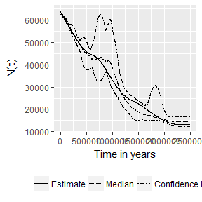

Notice that in this plot we kept $\alpha$ equal for all bootstrap estimations and only used 50 bootstrap samples. This is not optimal, and hence provide a slightly different result compared to that from the paper.

If the call of the `PlotCubSFS` do not include the results of any bootstrap samples, then the output of the call only includes two elements, not including `Ntboot`, and the two other elements are adjusted accordingly. Such that the plot do not include the median or confidence limits and `Ntdf` only holds two columns.

## The Akaike Information Criteria.

For assessing the fit of the estimated spline to the SFS dependent on the number of time points used, we suggest using the Akaike Information Criteria (AIC),

$$2\times 2m - 2\log\hat{L},$$
where $m$ is the number of time points ( not including 0) and $\hat{L}$ is the probability of the observed SFS under the multinomial distribution with probability vector determined from the estimated spline.

Say, we for the same data have two different fitted models:

- `resAlpha` estimated with 10 time points
- `resAlpha15` estimated with 15 time points

```r
set.seed(98765)
resAlpha15 <- estimateCubSFS(obsSFS,n.samples,n.knots=15,t_m=0.7633)
```

```
## alpha = 0.381966 and Mean GOF =  227.656
## alpha = 0.618034 and Mean GOF =  232.4621
## alpha = 0.236068 and Mean GOF =  244.2049
## alpha = 0.4709375 and Mean GOF =  242.5813
## alpha = 0.3262379 and Mean GOF =  228.2815
## alpha = 0.4059525 and Mean GOF =  246.3137
## alpha = 0.3786327 and Mean GOF =  245.9862
## alpha = 0.391128 and Mean GOF =  199.8842
## alpha = 0.3967905 and Mean GOF =  255.758
## alpha = 0.3876285 and Mean GOF =  233.3971
## alpha = 0.391128 and Mean GOF =  199.8842
```

Then we can compare the fit of the two models

```r
AicCubSFS(n.samples, resAlpha)
```

```
## AIC from SFS
##     2236.394
```

```r
AicCubSFS(n.samples, resAlpha15)
```

```
## AIC from SFS
##     2606.427
```

The model with smallest AIC is the best fit.

From the result of the bootstrap samples we can obtain the AIC based on the median of the bootstrap samples, instead of the results based on the information from the `estimateCubSFS` call on the observe SFS.

```r
AicCubSFS(n.samples, resAlpha,boot.res=boot.res)
```

```
##       AIC from SFS AIC from Bootstrap
##           2236.394           2318.565
```